# Proyecto fin de curso DataScientist K-School

Luis Espada

# Visualizacion datos con Shiny

Desde que conoci Shiny tuve claro que me podia resultar tremendamente util en mi trabajo diario en Carrefour. Gestiono los precios de cesion y de venta a las Franquicias Carrefour Express y elaboro muchos informes en excel para los responsables Comerciales y para los responsables de Explotacion de las tiendas

Shiny, combinado con R y PostgreSQL me permite poner a su disposicion una herramienta con la cual estos informes “estáticos” pasan a ser “dinámicos” y pueden interactuar con los datos a través de multiples criterios de seleccion.

He planteado este proyecto como un sistema **sencillo** y sobre todo **aplicable** a mi puesto de trabajo.

**Importante:** En los dos casos he ocultado todo dato significativo (códigos, estructuras, descripciones, …)

# Tecnologia empleada

- R
- Shiny

En la instalaciones de estos aplicativos en Carrefour combino estas tecnologias con PostgreSQL

Para presentar este trabajo he sustituido esos accesos directos a BB.DD por ficheros .csv

La instalacion para validar los dos aplicativos que planteo es muy sencilla. El unico cambio que debeis realizar es cambiar el directorio de trabajo en el fichero que lanza cada aplicacion

```
analisisSurtido.R
analisisTickets.R
```

Las librerias de R necesarias tambien son muy basicas

```
shiny
data.table
dplyr
ggplot2
```

# Aplicativo 1: Análisis Venta y Rentabilidad Surtido

Toma como entrada datos **referenciales del surtido** (estructura de categorias, proveedor, caracteristicas marketing, etc) y datos de **ventas por articulo - tienda**

A partir de estos datos se ofrecen al usuario cuatro posibles informes. La potencia de este sistema es que permite generar estos informes con una disponibilidad **inmediata** y combinando **criterios de seleccion referentes al Surtido** (*seccion-Grupo-Familia*, niveles que definen la estructura comercial del surtido, *Nivel de surtido*, *Proveedor* y/o *Caracteristicas Marketing de los articulos*) junto a **criterios de seleccion referentes a las Tiendas** (*region*, *rol*, *una tienda en concreto*)

Las dos primeras pestañas son informe referentes a articulos. La tercera y cuarta generan informes referentes a tiendas

# Pestaña 1: Indicadores Artículo

Muestra un data.table con datos referentes a los articulos-tiendas que cumplan los criterios seleccionados

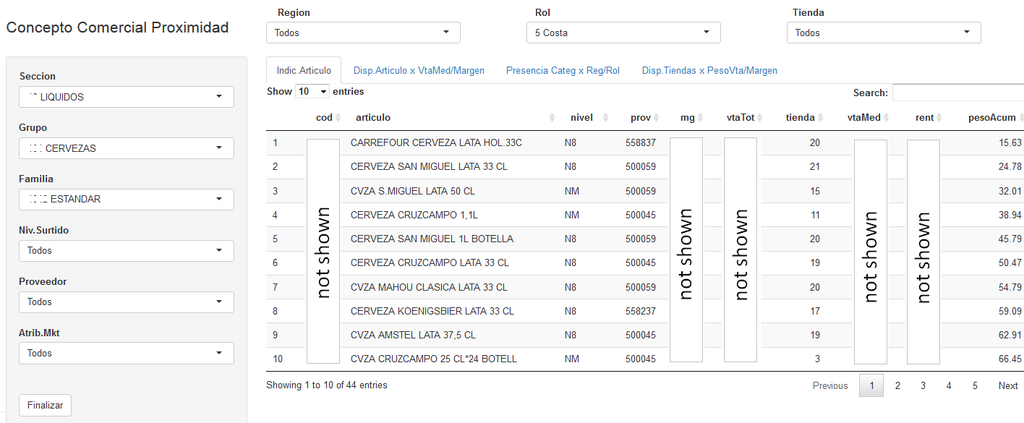

# Pestaña 2: Dispersion articulos por Venta media y Margen

Plotea los articulos que cumplan los articulos seleccionados en funcion de su venta media por tienda y su margen

En este informe he añadido dos criterios de seleccion especiales:

- filtro numerico para excluir articulos presentes en pocas tiendas (dado que uno de los ejes es la venta media por tienda pueden distorsionar la visualizacion articulos regionales de venta media elevada)
- check para excluir en la visualizacion outliers por su margen (margen con una desviacion respecto al margen medio de los articulos seleccionados superior a tres veces la desviacion tipica). Si no se marca el check se muestran los limites a partir de los que se considera outlier

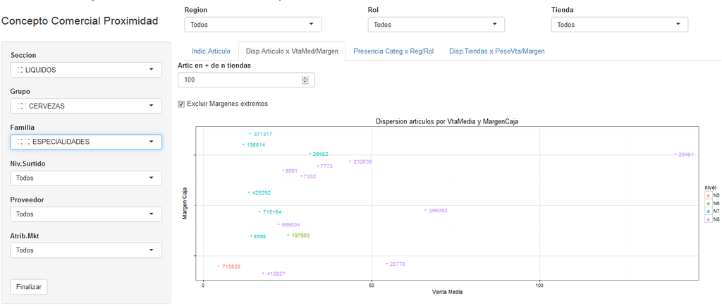

# Pestaña 3: Presencia de una categoria en las tiendas por Region / Rol

Como comentaba antes esta pestaña y la siguiente permiten realizar analisis sobre el comportamiento del surtido a nivel Tienda

Este informe genera un boxplot con la presencia del surtido (el peso que tiene este surtido sobre la venta total de la tienda) que cumpla los criterios de seleccion del menu lateral izquierdo (criterios de seleccion articulos)

Un radio button permite visualizar la informacion agrupando las tiendas por su Region geografica o por su Rol.

Es necesario seleccionar al menos un criterio en el menu lateral izquierdo para empezar a obtener datos significativos, puesto que si no calcula que todo el surtido de la tienda supone el 100% de la venta total de la tienda

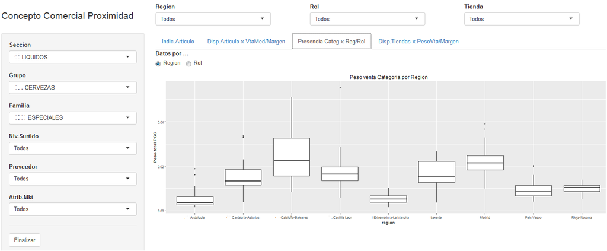